# Summarizing across groups

Answer key

2024-02-04

## 1. Summarizing by groups

For this, we will work with the Ache dataset again. It’s available as a .csv in your working directory. Load it with the `read.csv()` function and save it as `ache`

```r
ache <- read.csv("ache-hunting.csv")
```

If you don’t remember what the data looks like, go ahead and insert a code chunk and look at the structure of the data.

```r
str(ache)
```

```
## 'data.frame':    14364 obs. of  9 variables:
##  $ X       : int  1 2 3 4 5 6 7 8 9 10 ...
##  $ month   : int  10 10 10 10 10 10 10 2 2 2 ...
##  $ day     : int  2 3 4 5 6 7 8 6 7 8 ...
##  $ year    : int  1981 1981 1981 1981 1981 1981 1981 1982 1982 1982 ...
##  $ id      : int  3043 3043 3043 3043 3043 3043 3043 3043 3043 3043 ...
##  $ age     : int  67 67 67 67 67 67 67 68 68 68 ...
##  $ kg.meat : num  0 0 0 4.5 0 0 0 0 0 0 ...
##  $ hours   : num  6.97 9 1.55 8 3 7.5 9 7.3 8.1 6 ...
##  $ datatype: num  1 1 1 1 1 1 1 1 1 1 ...
```

#### Q1.1. Produce the summary statistics for `ache$age`. We’re going to use these to break the ages into four roughly equal groups, so make sure to use the median and quartiles. You can compute the quartiles with `quantile()`, specifying the 0.25 and 0.75 probabilities.

```r
median(ache$age)
```

```
## [1] 47
```

```r
quantile(ache$age, c(0.25, 0.5, 0.75))
```

```
## 25% 50% 75%
##  35  47  57
```

#### Q1.2 Use the computed Q1, median and Q3 values, combined with `mutate()` and an `ifelse()` statement to compute a new variable called “agegroup” with the levels: 1, 2, 3, 4. Go ahead and save the resulting dataframe as `ache`.

*Note – see exercise 1 for this week to refresh your nested `ifelse()` skills*

```r
ache <- ache %>%
  mutate(agegroup = ifelse(age < 35, 1, #note: this creates a numeric variable
                           ifelse(age < 47, 2,
                                  ifelse(age < 57, 3, 4))))
```

#### Q1.3. Based on our previous knowledge of the returns from Ache hunts (assignment 1 is due soon!), we know that a lot of hunts are unsuccessful. But of the hunts that are successful, is there any difference between age groups in average meat return? Make sure to also produce standard deviations!

Hint: Use `group_by()` and `summarise()`

```r
ache %>%
  filter(kg.meat > 0 )%>% # select out only hunts that are successful!
  group_by(agegroup)%>%
  summarise(mean = mean(kg.meat),
            sd = sd(kg.meat))
```

```
## # A tibble: 4 × 3
##   agegroup  mean    sd
##      <dbl> <dbl> <dbl>
## 1        1  7.06  9.39
## 2        2  6.97  8.26
## 3        3  6.87  8.55
## 4        4  5.98  4.34
```

#### Q1.4. Is there any difference in yield per hunt between the age groups when we exclude the hunts that are unsuccessful? Produce a plot to demonstrate the summary statistics you produced in Q1.3. Make sure to color your plot by age group and add informative labels on the title and axes.

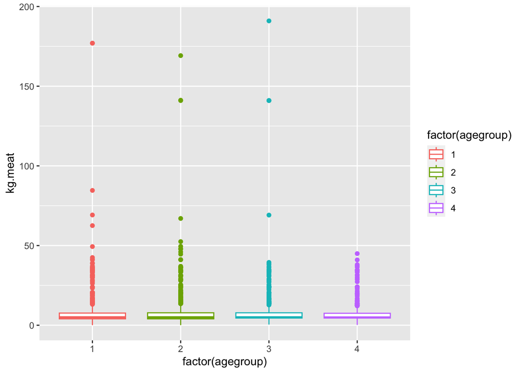

```r
ache %>%
  filter(kg.meat >0)%>%
  ggplot(aes(x = factor(agegroup), y = kg.meat, col = factor(agegroup)))+ #if you created a character vector you do not need to coerce to factor (but it will work!)
  geom_boxplot()
```